# GIS layers

@rvosa

2022-05-25

# Introduction

## Global Soil Dataset for use in Earth System Models (GSDE)

Shangguan, W., Dai, Y., Duan, Q., Liu, B. and Yuan, H., 2014. A Global Soil Data Set for Earth System Modeling. Journal of Advances in Modeling Earth Systems, 6: 249-263. doi:[10.1002/2013MS000293](https://doi.org/10.1002/2013MS000293)

From website:

> We developed a comprehensive, gridded Global Soil Dataset for use in Earth System Models (GSDE) and other applications as well. GSDE provides soil information including soil particle-size distribution, organic carbon, and nutrients, etc. and quality control information in terms of confidence level. GSDE is based on the Soil Map of the World and various regional and national soil databases, including soil attribute data and soil maps. We used a standardized data structure and data processing procedures to harmonize the data collected from various sources. We then used a soil type linkage method (i.e. taxotransfer rules) and the polygon linkage method to derive the spatial distribution of soil properties. To aggregate the attributes of different compositions of a mapping unit, we used three mapping approaches: area-weighting method, the dominant soil type method and the dominant binned soil attribute method. In the released gridded dataset, we used the area-weighting method as it will meet the demands of most applications. The dataset can be also aggregate to a lower resolution. The resolution is 30 arc-seconds (about 1 km at the equator). The vertical variation of soil property was captured by eight layers to the depth of 2.3 m (i.e. 0- 0.045, 0.045- 0.091, 0.091- 0.166, 0.166- 0.289, 0.289- 0.493, 0.493- 0.829, 0.829- 1.383 and 1.383- 2.296 m).

Data at: http://globalchange.bnu.edu.cn/research/soilw

### BulkDensity

The soil bulk density (BD) is the mass of soil material divided by the total volume of solids and pores. Because of lack of data, the BD is usually estimated from the sand, silt, and clay contents in LSMs. The BD is inversely related to the porosity of a soil. The BD impacts the soil water retention properties and soil hydraulic conductivity.

Apparently, soil is less dense at high latitudes.

```r
GDALinfo("../data/soil/5m/BulkDensity.tif")
```

```
## rows        1800
## columns     4320
## bands       1
## lower left origin.x        -180
## lower left origin.y        -60
## res.x       0.08333333
## res.y       0.08333333
## ysign       -1
## oblique.x   0
## oblique.y   0
## driver      GTiff
## projection  +proj=longlat +ellps=WGS84 +towgs84=0,0,0,0,0,0,0 +no_defs
## file        ../data/soil/5m/BulkDensity.tif
## apparent band summary:
##    GDType hasNoDataValue NoDataValue blockSize1 blockSize2
## 1 Float32           TRUE    -3.4e+38          1       4320
## apparent band statistics:
##   Bmin Bmax    Bmean      Bsd
## 1   16  200 124.0051 24.48446
## Metadata:
## AREA_OR_POINT=Area
```

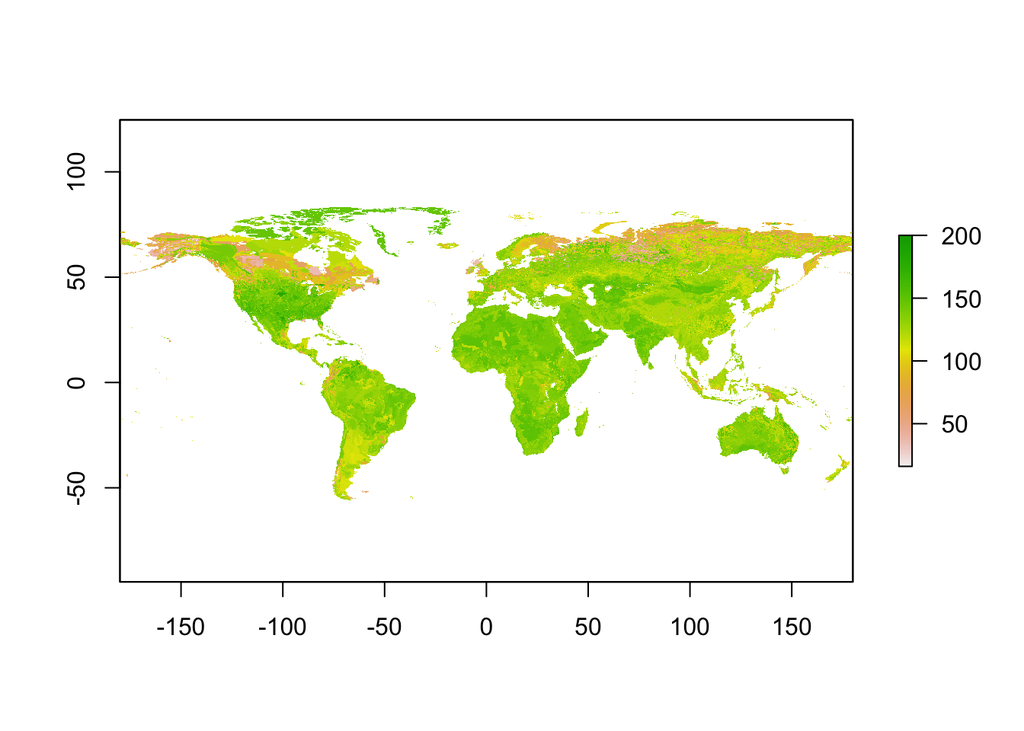

```r
r <- raster("../data/soil/5m/BulkDensity.tif", values=T, nrows=1800, ncols=4320, xmn=-180, xmx=180, ymn=-60, ymx=60)
plot(r)
```

### ClayPercentage

In the GSDE, the areas with high sand content were found in the Africa, Canada, Australia, Central Asia, and the Arabian Peninsula, most of which are deserts. Usually, areas with high sand content had low clay content, and vice versa. High clay content appeared in the South America, Central Africa, India, and East Australia.

**Note**: there will be a lot of local structure, e.g. clay content should also be high locally in river valleys.

```r
GDALinfo("../data/soil/5m/ClayPercentage.tif")
```

```
## rows        1800
## columns     4320
## bands       1
## lower left origin.x        -180
## lower left origin.y        -60
## res.x       0.08333333
## res.y       0.08333333
## ysign       -1
## oblique.x   0
## oblique.y   0
## driver      GTiff
## projection  +proj=longlat +ellps=WGS84 +towgs84=0,0,0,0,0,0,0 +no_defs
## file        ../data/soil/5m/ClayPercentage.tif
## apparent band summary:
##    GDType hasNoDataValue NoDataValue blockSize1 blockSize2
## 1 Float32           TRUE    -3.4e+38          1       4320
## apparent band statistics:
##   Bmin Bmax    Bmean      Bsd
## 1    0   94 17.92453 10.94358
## Metadata:
## AREA_OR_POINT=Area
```

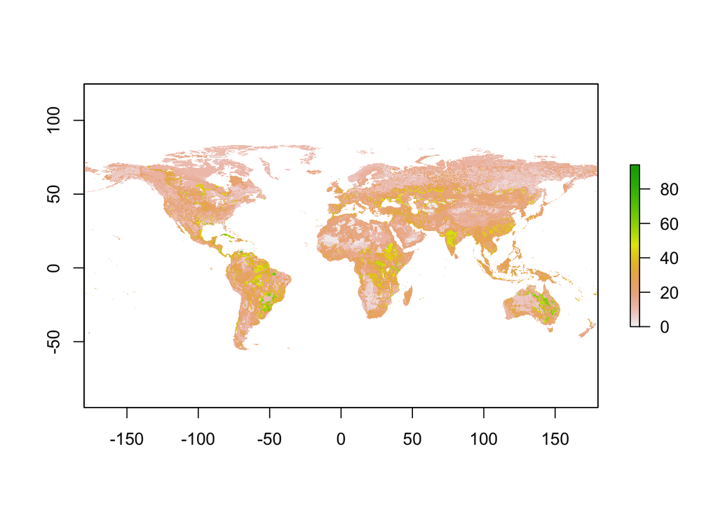

```r
r <- raster("../data/soil/5m/ClayPercentage.tif", values=T, nrows=1800, ncols=4320, xmn=-180, xmx=180, ymn=-60, ymx=60)
plot(r)
```

### OrganicCarbon

The soil organic carbon (SOC) increases the water-holding capacity of soil. The SOC is also important to plant growth and is a major factor in the overall health of soil. Usually, the SOC is not measured directly in a soil survey but is estimated from the soil organic matter. In the GSDE, high SOC was primarily found in the high latitudes of the Northern Hemisphere. Low SOC was found in the desert areas.

```r
GDALinfo("../data/soil/5m/OrganicCarbon.tif")
```

```
## rows        1800
## columns     4320
## bands       1
## lower left origin.x        -180
## lower left origin.y        -60
## res.x       0.08333333
## res.y       0.08333333
## ysign       -1
## oblique.x   0
## oblique.y   0
## driver      GTiff
## projection  +proj=longlat +ellps=WGS84 +towgs84=0,0,0,0,0,0,0 +no_defs
## file        ../data/soil/5m/OrganicCarbon.tif
## apparent band summary:
##    GDType hasNoDataValue NoDataValue blockSize1 blockSize2
## 1 Float32           TRUE    -3.4e+38          1       4320
## apparent band statistics:
##   Bmin Bmax    Bmean      Bsd
## 1    0 7496 371.3913 691.2343
## Metadata:
## AREA_OR_POINT=Area
```

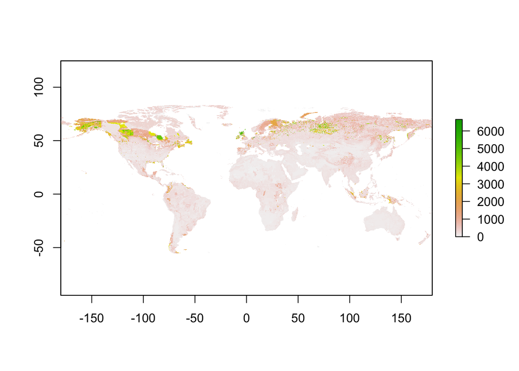

```r
r <- raster("../data/soil/5m/OrganicCarbon.tif", values=T, nrows=1800, ncols=4320, xmn=-180, xmx=180, ymn=-60, ymx=60)
plot(r)
```

### PhCaCL

pH, measured in CaCl2 solution. A low pH means an acidic soil, e.g. in the Amazonian and Congo basins, but also at high latitudes in Eurasia and North America. In both cases, high amounts of rain as well as intense decomposition processes serve to lower the pH compared to more arid regions, which are more alkaline.

```r
GDALinfo("../data/soil/5m/PhCaCL.tif")
```

```
## rows        1800
## columns     4320
## bands       1
## lower left origin.x        -180
## lower left origin.y        -60
## res.x       0.08333333
## res.y       0.08333333
## ysign       -1
## oblique.x   0
## oblique.y   0
## driver      GTiff
## projection  +proj=longlat +ellps=WGS84 +towgs84=0,0,0,0,0,0,0 +no_defs
## file        ../data/soil/5m/PhCaCL.tif
## apparent band summary:
##    GDType hasNoDataValue NoDataValue blockSize1 blockSize2
## 1 Float32           TRUE    -3.4e+38          1       4320
## apparent band statistics:
##   Bmin Bmax    Bmean      Bsd
## 1   26   87 59.15195 12.11148
## Metadata:
## AREA_OR_POINT=Area
```

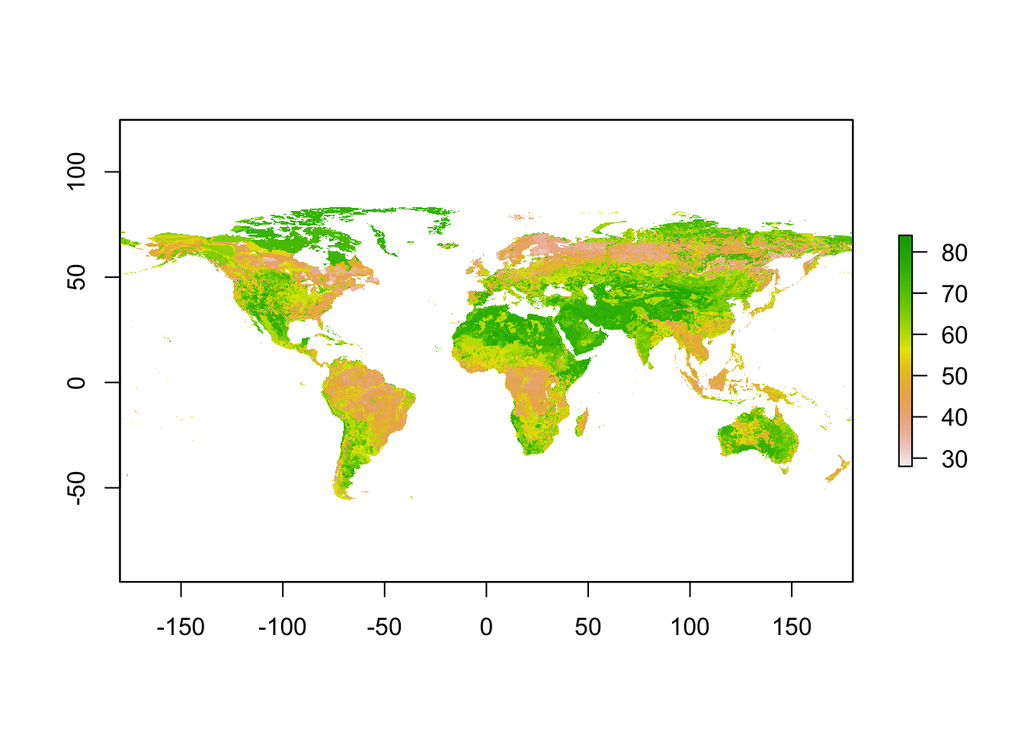

```r
r <- raster("../data/soil/5m/PhCaCL.tif", values=T, nrows=1800, ncols=4320, xmn=-180, xmx=180, ymn=-60, ymx=60)
plot(r)
```